# Bakery Sales

Matthew Edwards

2022-11-22

## Summary

A bakery in France would like to produce the right number of products each day. Too few products would result in monetary loss and too many products would result in food waste. The baker has noticed that product demand is affected by weather. Therefore to produce the right number of products for each day the baker would like a forecasting model for each product based on weather.

## Data

There are two available data sets. The first is the `sales` data which includes the time and date each product was purchased along with the quantity and unit price. The second is the `weather` data which includes daily weather variables (e.g., maximum temperature, wind speed and pressure) over the period the `sales` data was collected. The `sales` data suggests that there are approximately 149 different products. The five most popular products over this period are:

| Article | Quantity |
| --- | --- |
| Traditional Baguette | 117463 |
| Croissant | 29654 |
| Pain Au Chocolat | 25236 |
| Coupe | 23505 |
| Banette | 22732 |

For this project we will focus on prototyping a forecasting model for the Traditional Baguette. The following figure displays an STL decomposition of the time series. It suggests non-stationary trend and seasonal components and heteroscedastic errors. A forecasting model for this data will require exogenous variables to account for the non-stationary trend and seasonal components. The hetroscedastic errors will be considerably harder to model.

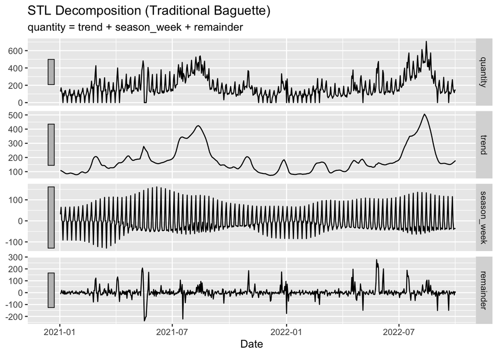

## Model

To account for the non-stationary trend the average temperature, wind speed and pressure variables where added as exogenous variables. An ARMA model was used with both auto regressive and moving average components to account for the temporal correlation. Weekly dummy variables where added to account for the weekly seasonality. The following residual diagnostics suggest that most of the temporal correlation and non-stationary trend and seasonality is accounted for. However, there is still unaccounted for heteroscedasticity in the errors. Accounting for this would require considerably more exploratory data analysis.

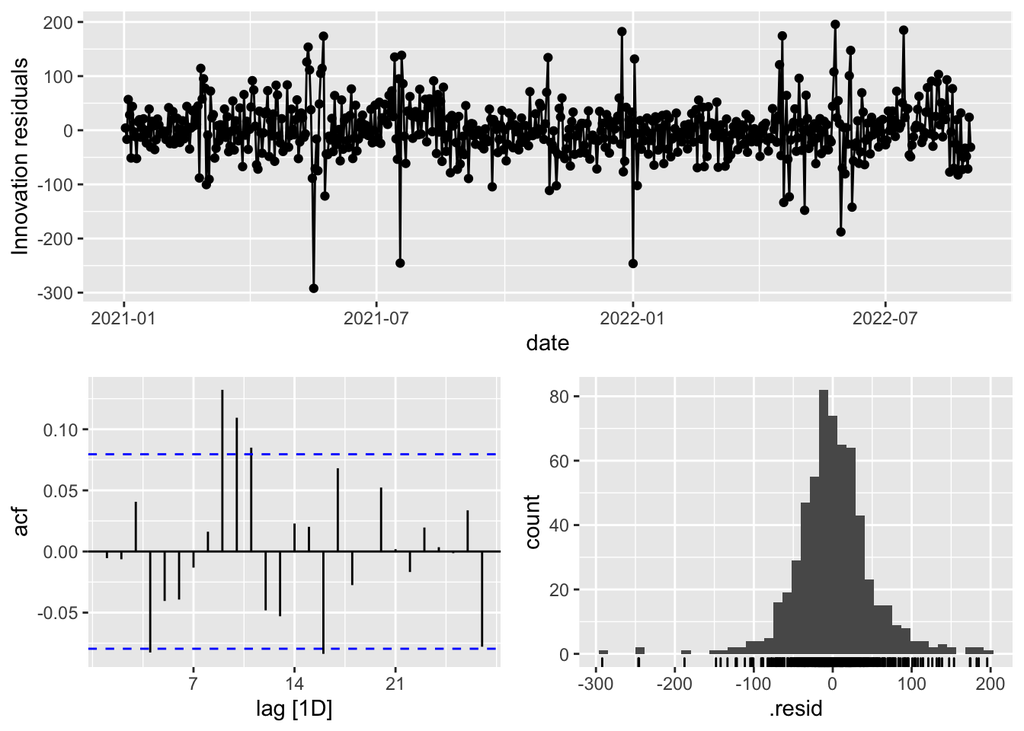

## Results

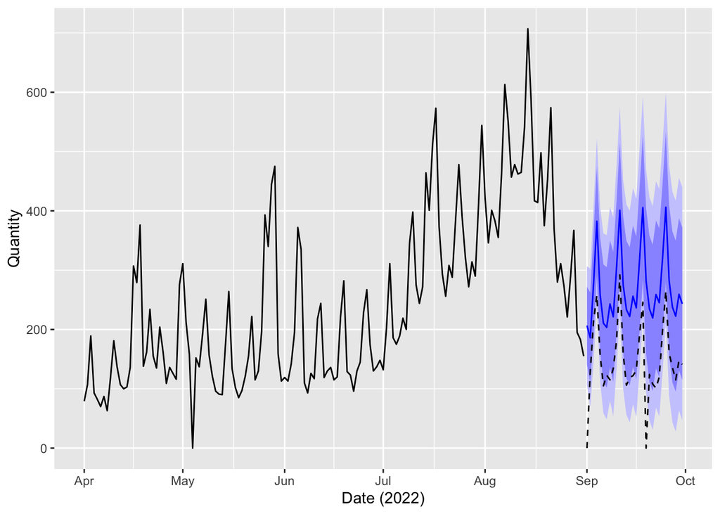

The predictions in the last month of the data set had a mean absolute error of approximately 122.